# Time Series Model for USA Air Passenger Miles Using Python

### November 6, 2019

Template Credit: Adapted from a template made available by Dr. Jason Brownlee of Machine Learning Mastery. https://machinelearningmastery.com/

SUMMARY: The purpose of this project is to construct a time series prediction model and document the end-to-end steps using a template. The USA Air Passenger Miles dataset is a time series situation where we are trying to forecast future outcomes based on past data points.

ANALYSIS: The baseline prediction (or persistence) for the dataset resulted in an RMSE of 1.770. After performing a grid search for the most optimal ARIMA parameters, the final ARIMA non-seasonal order was (1, 1, 2) with the seasonal order being (1, 1, 1, 12). Furthermore, the chosen model processed the validation data with an RMSE of 0.437, which was better than the baseline model as expected.

CONCLUSION: For this dataset, the chosen ARIMA model achieved a satisfactory result and should be considered for further modeling.

Dataset Used: Monthly U.S Air Passenger Miles January 1960 through December 1977

Dataset ML Model: Time series forecast with numerical attributes

Dataset Reference: Rob Hyndman and Yangzhuoran Yang (2018). tsdl: Time Series Data Library. v0.1.0. https://pkg.yangzhuoranyang./tsdl/.

The project aims to touch on the following areas:

- Document a predictive modeling problem end-to-end
- Explore data cleaning and transformation options
- Explore various algorithms for baselining the model performance
- Explore tuning techniques for improving the model performance

A time series predictive modeling project genrally can be broken down into about five major tasks:

1. Define Problem and Acquire Data
2. Inspect and Explore Data
3. Clean and Pre-Process Data
4. Fit and Evaluate Models
5. Finalize Model

## Section 1. Define Problem and Acquire Data

### 1.a) Load Libraries

```python
# Set the warning message filter
import warnings
warnings.filterwarnings("ignore", category=FutureWarning)
warnings.filterwarnings("ignore", category=UserWarning)
```

```python
import numpy as np
import pandas as pd
import matplotlib.pyplot as plt
import seaborn as sns
import os
import math
import smtplib
import pmdarima as pm
from datetime import datetime
from email.message import EmailMessage
from sklearn.metrics import mean_squared_error
from statsmodels.tsa.statespace.sarimax import SARIMAX
from statsmodels.tsa.stattools import adfuller
from statsmodels.tsa.seasonal import seasonal_decompose
from statsmodels.graphics.tsaplots import plot_acf
from statsmodels.graphics.tsaplots import plot_pacf
```

### 1.b) Set up the controlling parameters and functions

```python
# Create the random seed number for reproducible results
seedNum = 888

# Set up the number of CPU cores available for multi-thread processing
n_jobs = 1

# Set up the verbose flag to print detailed messages for debugging (setting True will activate!)
verbose = False

# Set up the flag to stop sending progress emails (setting to True will send status emails!)
notifyStatus = False
```

```python
# Set up the email notification function
def email_notify(msg_text):
    sender = os.environ.get('MAIL_SENDER')
    receiver = os.environ.get('MAIL_RECEIVER')
    gateway = os.environ.get('SMTP_GATEWAY')
    smtpuser = os.environ.get('SMTP_USERNAME')
    password = os.environ.get('SMTP_PASSWORD')
    if sender==None or receiver==None or gateway==None or smtpuser==None or password==None:
        sys.exit("Incomplete email setup info. Script Processing Aborted!!!")
    msg = EmailMessage()
    msg.set_content(msg_text)
    msg['Subject'] = 'Notification from Python Time Series Script'
    msg['From'] = sender
    msg['To'] = receiver
    server = smtplib.SMTP(gateway, 587)
    server.starttls()
    server.login(smtpuser, password)
    server.send_message(msg)
    server.quit()
```

```python
if (notifyStatus): email_notify("Library and Data Loading has begun! "+datetime.now().strftime('%a %B %d, %Y %I:%M:%S %p'))
```

### 1.c) Acquire and Load the Data

```python
startTimeScript = datetime.now()
```

```python
# load the dataset and the necessary data structure
time_series = pd.read_csv('tsdl200.csv', index_col='idx', parse_dates=True)

# Sample code for subsetting the time-series data
# original_series = pd.read_csv('minimum-daily-temperatures.csv', index_col='Date', parse_dates=True)
# time_series = original_series['1986':'1990']
```

```python
target_col = time_series.columns[0]
lower_bound = 'lower ' + target_col
upper_bound = 'upper ' + target_col
print('The target column of the time series is:', target_col)
print('The forecast boundary columns are:', lower_bound, '&', upper_bound)
```

```
The target column of the time series is: values
The forecast boundary columns are: lower values & upper values
```

```python
time_series.info()
```

```
<class 'pandas.core.frame.DataFrame'>
DatetimeIndex: 216 entries, 1960-01-01 to 1977-12-01
Data columns (total 1 columns):
values    216 non-null float64
dtypes: float64(1)
memory usage: 3.4 KB
```

```python
time_series.head(10)
```

| idx | values |
| --- | --- |
| 1960-01-01 | 2.42 |
| 1960-02-01 | 2.14 |
| 1960-03-01 | 2.28 |
| 1960-04-01 | 2.50 |
| 1960-05-01 | 2.44 |
| 1960-06-01 | 2.72 |
| 1960-07-01 | 2.71 |
| 1960-08-01 | 2.74 |
| 1960-09-01 | 2.55 |
| 1960-10-01 | 2.49 |

```python
time_series.tail(10)
```

| idx | values |
| --- | --- |
| 1977-03-01 | 15.46 |
| 1977-04-01 | 15.39 |
| 1977-05-01 | 15.34 |
| 1977-06-01 | 17.02 |
| 1977-07-01 | 18.85 |
| 1977-08-01 | 19.49 |
| 1977-09-01 | 15.61 |
| 1977-10-01 | 16.16 |
| 1977-11-01 | 14.84 |
| 1977-12-01 | 17.04 |

```python
if (notifyStatus): email_notify("Library and Data Loading completed! "+datetime.now().strftime('%a %B %d, %Y %I:%M:%S %p'))
```

## Section 2. Inspect and Explore Data

```python
if (notifyStatus): email_notify("Data Inspection and Exploration has begun! "+datetime.now().strftime('%a %B %d, %Y %I:%M:%S %p'))
```

### 2.a) Summary Statistics of the Time Series Data

Summary statistics provide a quick look at the limits of observed values. It can help to get a quick idea of what we are working with.

```python
# Summary statistics of time series
print(time_series.describe())
```

```
           values
count  216.000000
mean     8.327546
std      4.924629
min      1.820000
25%      3.505000
50%      7.100000
75%     12.902500
max     19.490000
```

### 2.b) Line Plot of the Time Series Data

A line plot of a time series can provide a lot of insight into the problem. Some observations from the plot can include:

- Whether the trend appears to be level around the mean
- Whether there appear to be any obvious outliers

The ARIMA(p,d,q) model requires three parameters and assumes that we are working with a stationary time series.

The ADF results should show that the test statistic value is smaller than the critical value at 5% if the time series is stationary. This suggests that we can reject the null hypothesis (i.e. a low probability that the result is a statistical fluke).

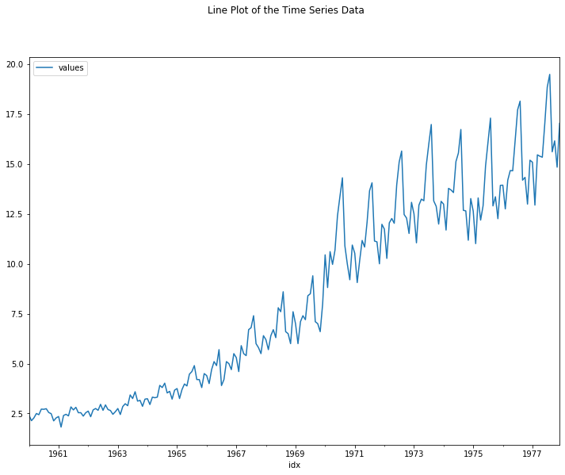

```python
# Line plots of time series
fig, ax = plt.subplots(figsize=(12,9))
fig.suptitle('Line Plot of the Time Series Data')
time_series.plot(ax=ax)
plt.show()
```

### 2.c) Histogram and Density Plots of the Time Series Data

Reviewing plots of the density of observations can provide further insight into the structure of the data. Some observations from the plots can include:

- Whether the distribution is Gaussian
- Whether the distribution has a long tail and may suggest the need for data transformation

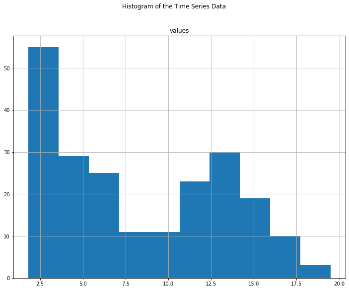

```python
# Line plots of time series
fig, ax = plt.subplots(figsize=(12,9))
fig.suptitle('Histogram of the Time Series Data')
time_series.hist(ax=ax)
plt.show()
```

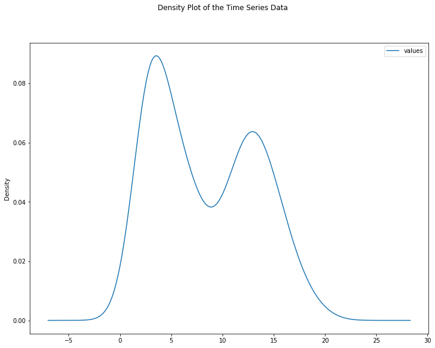

```python
# Line plots of time series
fig, ax = plt.subplots(figsize=(12,9))
fig.suptitle('Density Plot of the Time Series Data')
time_series.plot(kind='kde', ax=ax)
plt.show()
```

### 2.d) Box and Whisker Plots of the Time Series Data

We can group or aggregate the data and get a better idea of the spread of observations. Some observations from reviewing the plot can include:

- Whether the median values for each grouping shows any significant trend
- Whether the spread, or middle 50% of the data, shows any significant variability
- Whether there are outliers in some grouping

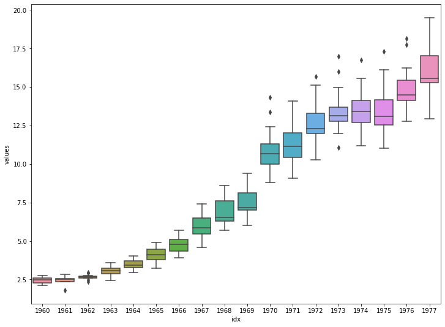

```python
# boxplots of time series
fig, ax = plt.subplots(figsize=(12,9))
squeezed = time_series.squeeze()
sns.boxplot(squeezed.index.year, squeezed, ax=ax)
plt.show()
```

```python
if (notifyStatus): email_notify("Data Inspection and Exploration completed! "+datetime.now().strftime('%a %B %d, %Y %I:%M:%S %p'))
```

## Section 3. Data Transformation and Stationarity Tests

```python
if (notifyStatus): email_notify("Data Cleaning and Pre-Processing has begun! "+datetime.now().strftime('%a %B %d, %Y %I:%M:%S %p'))
```

### Section 3.a) Data Transformation

```python
# Resampling the time series into monthly average for the ease of modeling
# original_series = time_series
# resample = original_series.resample('M')
# time_series = resample.mean()
# time_series.head(10)
```

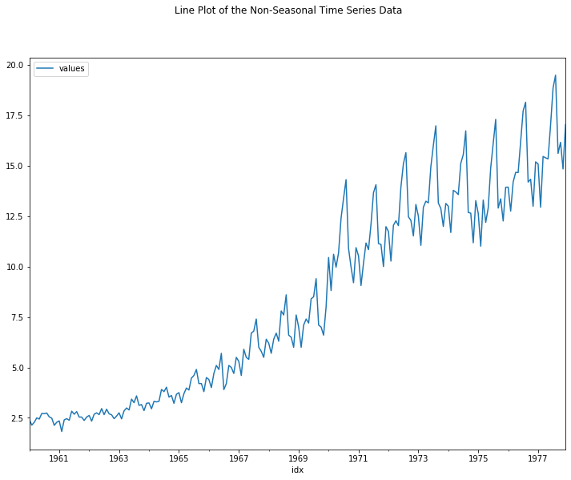

```python
# Line plots of the transformed time series
fig, ax = plt.subplots(figsize=(12,9))
fig.suptitle('Line Plot of the Non-Seasonal Time Series Data')
time_series.plot(ax=ax)
plt.show()
```

### Section 3.b) Test for Stationarity

```python
# Check if stationary
result = adfuller(time_series[target_col])
print('ADF Statistic: %f' % result[0])
print('p-value: %f' % result[1])
print('Critical Test Statistics Values:')
for key, value in result[4].items():
    print('\t%s: %.3f' % (key, value))
```

```
ADF Statistic: 0.315357
p-value: 0.978038
Critical Test Statistics Values:
	1%: -3.463
	5%: -2.876
	10%: -2.574
```

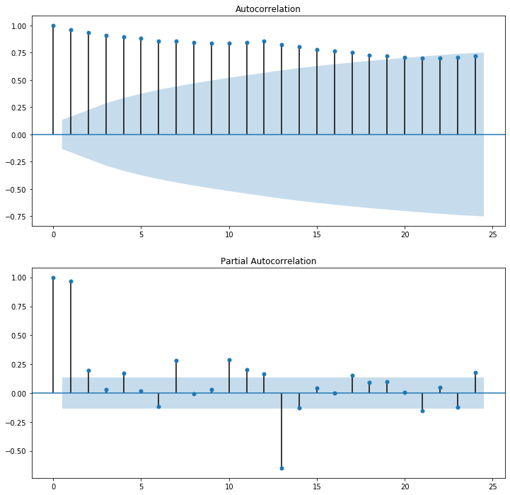

```python
# ACF and PACF plots of the time series data
fig, (ax1, ax2) = plt.subplots(2, 1, figsize=(12,12))
plot_acf(time_series, ax=ax1)
plot_pacf(time_series, ax=ax2)
plt.show()
```

### 3.c) Test for Stationarity of Non-Seasonal Time Series Data

Occasionally a time series may look non-stationary on the first look. We can make it stationary by differencing the series and using a statistical test to confirm that the differenced result is stationary. Rejecting the null hypothesis means that the process has no unit root, and in turn that the time series is stationary or does not have time-dependent structure.

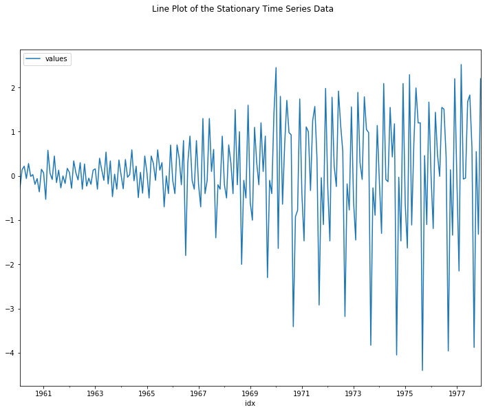

```python
# Create a differenced series
stationary_ns = time_series.diff().dropna()

# Plot differenced data
fig, ax = plt.subplots(figsize=(12,9))
fig.suptitle('Line Plot of the Stationary Time Series Data')
stationary_ns.plot(ax=ax)
plt.show()
```

```python
# Check for stationarity
result = adfuller(stationary_ns[target_col])
print('ADF Statistic: %f' % result[0])
print('p-value: %f' % result[1])
print('Critical Test Statistics Values:')
for key, value in result[4].items():
    print('\t%s: %.3f' % (key, value))
```

```
ADF Statistic: -3.748420
p-value: 0.003481
Critical Test Statistics Values:
	1%: -3.463
	5%: -2.876
	10%: -2.574
```

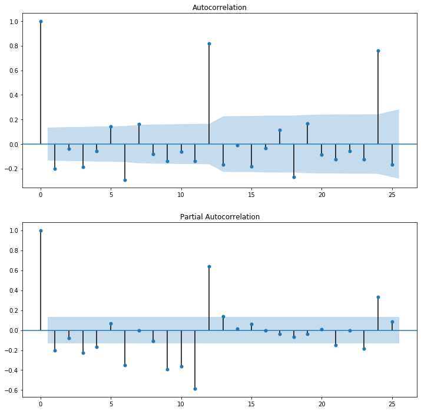

```python
# ACF and PACF plots of the stationary time series
lags = 25
fig, (ax1, ax2) = plt.subplots(2, 1, figsize=(12,12))
plot_acf(stationary_ns, lags=lags, ax=ax1)
plot_pacf(stationary_ns, lags=lags, ax=ax2)
plt.show()
```

### 3.d) Seasonal Decomposition for Seasonal Time Series Data

```python
# Set the initial seasonal frequency parameter
seasonal_freq = 12
```

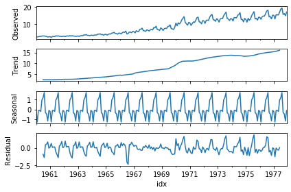

```python
# Perform seasonal decomposition to observe the seasonal frequency
decomp_results = seasonal_decompose(time_series, freq=seasonal_freq)
decomp_results.plot()
plt.show()
```

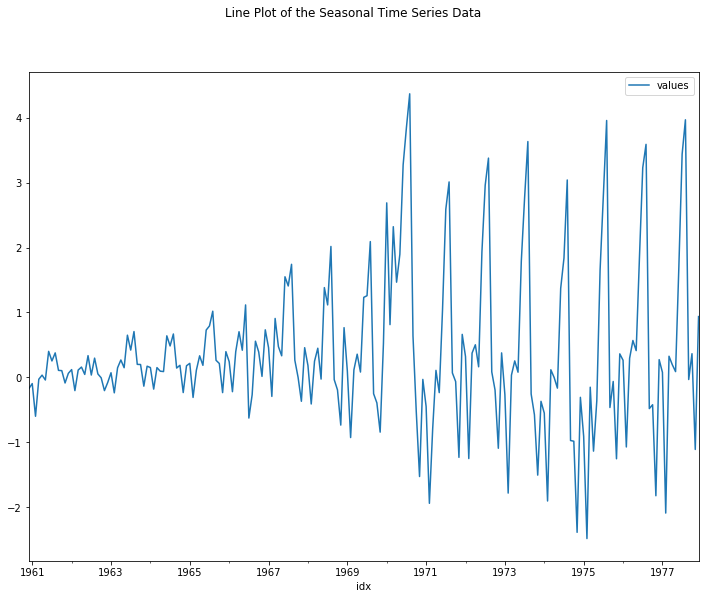

```python
# Create a seasonal series
N = seasonal_freq
seasonal_series = time_series - time_series.rolling(N).mean()
seasonal_series = seasonal_series.dropna()

# Line plots of the seasonal time series
fig, ax = plt.subplots(figsize=(12,9))
fig.suptitle('Line Plot of the Seasonal Time Series Data')
seasonal_series.plot(ax=ax)
plt.show()
```

```python
# Check for stationarity
result = adfuller(seasonal_series[target_col])
print('ADF Statistic: %f' % result[0])
print('p-value: %f' % result[1])
print('Critical Test Statistics Values:')
for key, value in result[4].items():
    print('\t%s: %.3f' % (key, value))
```

```
ADF Statistic: -3.996591
p-value: 0.001428
Critical Test Statistics Values:
	1%: -3.465
	5%: -2.877
	10%: -2.575
```

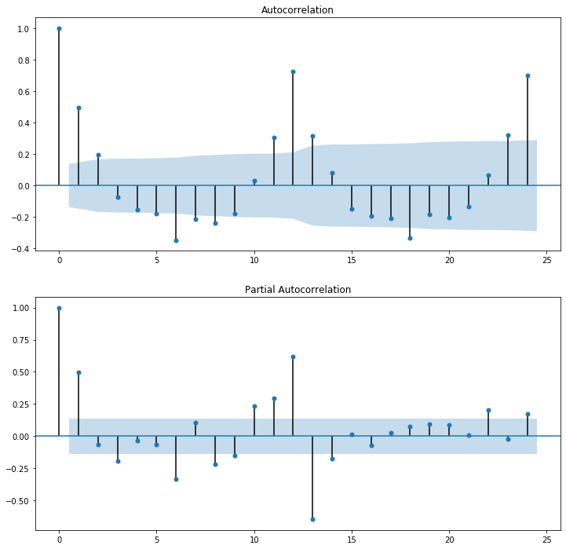

```python
# ACF and PACF plots of the time series data
lag = seasonal_freq * 2
fig, (ax1, ax2) = plt.subplots(2, 1, figsize=(12,12))
plot_acf(seasonal_series, lags=lag, ax=ax1)
plot_pacf(seasonal_series, lags=lag, ax=ax2)
plt.show()
```

### 3.e) Test for Stationarity of Seasonal Time Series Data

Occasionally a time series may look non-stationary on the first look. We can make it stationary by differencing the series and using a statistical test to confirm that the differenced result is stationary. Rejecting the null hypothesis means that the process has no unit root, and in turn that the time series is stationary or does not have time-dependent structure.

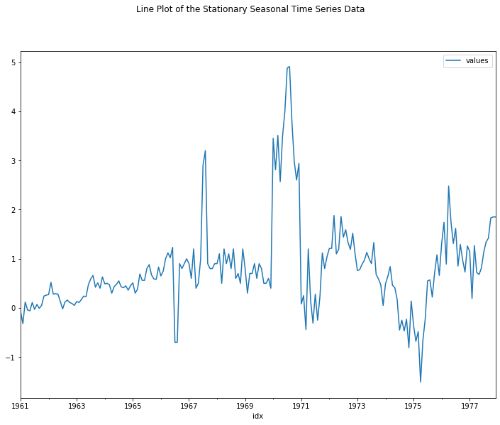

```python
# Create a differenced series
stationary_ss = time_series.diff(seasonal_freq).dropna()

# Plot differenced data
fig, ax = plt.subplots(figsize=(12,9))
fig.suptitle('Line Plot of the Stationary Seasonal Time Series Data')
stationary_ss.plot(ax=ax)
plt.show()
```

```python
# Check for stationarity
result = adfuller(stationary_ss[target_col])
print('ADF Statistic: %f' % result[0])
print('p-value: %f' % result[1])
print('Critical Test Statistics Values:')
for key, value in result[4].items():
    print('\t%s: %.3f' % (key, value))
```

```
ADF Statistic: -2.391473
p-value: 0.144157
Critical Test Statistics Values:
	1%: -3.465
	5%: -2.877
	10%: -2.575
```

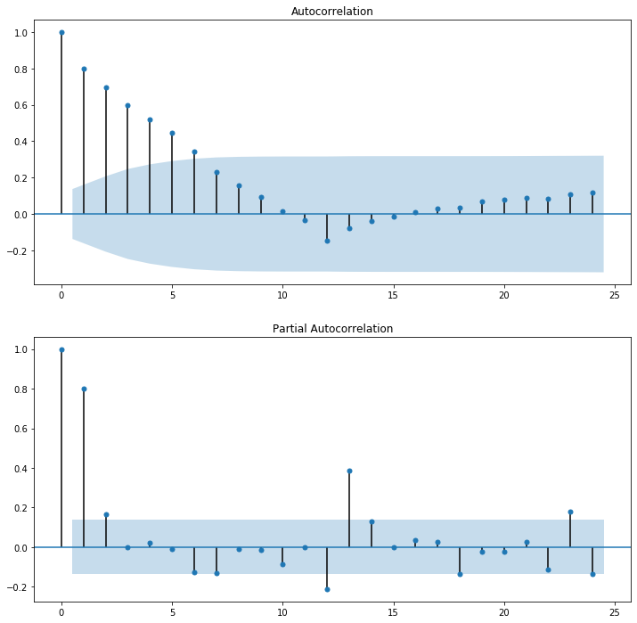

```python
# ACF and PACF plots of the stationary time series
lags = seasonal_freq * 2
fig, (ax1, ax2) = plt.subplots(2, 1, figsize=(12,12))
plot_acf(stationary_ss, lags=lags, ax=ax1)
plot_pacf(stationary_ss, lags=lags, ax=ax2)
plt.show()
```

```python
if (notifyStatus): email_notify("Data Cleaning and Pre-Processing completed! "+datetime.now().strftime('%a %B %d, %Y %I:%M:%S %p'))
```

## Section 4. Fit and Evaluate Models

In this section, we will develop Autoregressive Integrated Moving Average or ARIMA models for the problem. We will first establish a persistent model. Next we will use a grid search approach to look for an optimal ARIMA model. This will be followed by a third step of investigating the residual errors of the chosen model.

- Establish the Persistent Model
- Automatically Configure the ARIMA
- Review Residual Errors

```python
if (notifyStatus): email_notify("Model Fitting and Evaluation has begun! "+datetime.now().strftime('%a %B %d, %Y %I:%M:%S %p'))
```

### 4.a) Establish the Persistent Model

The first step before getting bogged down in data analysis and modeling is to establish a baseline of performance. This will provide both a template for evaluating models using the proposed test harness and a performance measure by which all more elaborate predictive models can be compared.

The baseline prediction for time series forecasting is called the naive forecast, or persistence. This is where the observation from the previous time step is used as the prediction for the observation at the next time step.

#### 4.a.iii) Establish the Persistent Model as Baseline

```python
# Prepare and evaluate a persistence model
X = time_series.values
X = X.astype('float32')
train_pct = 0.80
train_size = int(len(X) * train_pct)
test_size = len(X) - train_size
train_ts, test_ts = X[0:train_size], X[train_size:]

# walk-forward validation
history = [x for x in train_ts]
predictions = list()
for i in range(len(test_ts)):
    yhat = history[-1]
    predictions.append(yhat)
    obs = test_ts[i]
    history.append(obs)
    print('>Predicted=%.3f, Expected=%3.f' % (yhat, obs))

# Calculate performance
rmse = math.sqrt(mean_squared_error(test_ts, predictions))
print('RMSE for the persistent model is: %.3f' % rmse)
```

```
>Predicted=13.700, Expected= 14
>Predicted=13.570, Expected= 15
>Predicted=15.120, Expected= 16
>Predicted=15.550, Expected= 17
>Predicted=16.730, Expected= 13
>Predicted=12.680, Expected= 13
>Predicted=12.650, Expected= 11
>Predicted=11.180, Expected= 13
>Predicted=13.270, Expected= 13
>Predicted=12.640, Expected= 11
>Predicted=11.010, Expected= 13
>Predicted=13.300, Expected= 12
>Predicted=12.190, Expected= 13
>Predicted=12.910, Expected= 15
>Predicted=14.900, Expected= 16
>Predicted=16.100, Expected= 17
>Predicted=17.300, Expected= 13
>Predicted=12.900, Expected= 13
>Predicted=13.360, Expected= 12
>Predicted=12.260, Expected= 14
>Predicted=13.930, Expected= 14
>Predicted=13.940, Expected= 13
>Predicted=12.750, Expected= 14
>Predicted=14.190, Expected= 15
>Predicted=14.670, Expected= 15
>Predicted=14.660, Expected= 16
>Predicted=16.210, Expected= 18
>Predicted=17.720, Expected= 18
>Predicted=18.150, Expected= 14
>Predicted=14.190, Expected= 14
>Predicted=14.330, Expected= 13
>Predicted=12.990, Expected= 15
>Predicted=15.190, Expected= 15
>Predicted=15.090, Expected= 13
>Predicted=12.940, Expected= 15
>Predicted=15.460, Expected= 15
>Predicted=15.390, Expected= 15
>Predicted=15.340, Expected= 17
>Predicted=17.020, Expected= 19
>Predicted=18.850, Expected= 19
>Predicted=19.490, Expected= 16
>Predicted=15.610, Expected= 16
>Predicted=16.160, Expected= 15
>Predicted=14.840, Expected= 17
RMSE for the persistent model is: 1.770
```

### 4.b) Grid Search of ARIMA Hyperparameters

We want to find a model that can do better than the persistence model on this dataset. To confirm this analysis, we can grid search a suite of ARIMA hyperparameters.

In this section, we will search values of p, d, and q for combinations (skipping those that fail to converge), and find the combination that results in the best performance. We will use a grid search to explore all combinations in a subset of integer values.

```python
if (notifyStatus): email_notify("ARIMA Hyperparameters Search has begun! "+datetime.now().strftime('%a %B %d, %Y %I:%M:%S %p'))
```

```python
# Set the initial P, D, and Q order parameters for non-seasonal ARIMA modeling
start_p = 0
start_d = None
start_q = 0
max_p = 5
max_d = 2
max_q = 5
```

```python
# Set the initial P, D, and Q order parameters for seasonal ARIMA modeling
start_P = 0
start_D = None
start_Q = 0
max_P = 2
max_D = 1
max_Q = 2
```

```python
# Testing the time series data for suggestions on the differencing term
start_d = pm.arima.ndiffs(time_series)
print('The suggested non-seasonal differencing term is:', start_d)
if (seasonal_freq != 0):
    start_D = pm.arima.nsdiffs(time_series, m = seasonal_freq)
    print('The suggested seasonal differencing term is:', start_D)
```

```
The suggested non-seasonal differencing term is: 1
The suggested seasonal differencing term is: 1
```

```python
print('The initial non-seasonal parameters are: p =', start_p, '| d =', start_d, '| q =', start_q)
print('The maximum non-seasonal parameters are: max_p =', max_p, '| max_d =', max_d, '| max_q =', max_q)
print('The initial seasonal parameters are: P =', start_P, '| D =', start_D, '| Q =', start_Q, '| m =', seasonal_freq)
print('The maximum seasonal parameters are: max_P =', max_P, '| max_D =', max_D, '| max_Q =', max_Q)
```

```
The initial non-seasonal parameters are: p = 0 | d = 1 | q = 0
The maximum non-seasonal parameters are: max_p = 5 | max_d = 2 | max_q = 5
The initial seasonal parameters are: P = 0 | D = 1 | Q = 0 | m = 12
The maximum seasonal parameters are: max_P = 2 | max_D = 1 | max_Q = 2
```

```python
# Do an automated stepwise search of ARIMA parameters
if (seasonal_freq == 0):
    stepwise_results = pm.auto_arima(time_series, seasonal = False, stepwise = True, trace = True, suppress_warnings = True, random_state = seedNum)
else:
    stepwise_results = pm.auto_arima(time_series, seasonal = True, m = seasonal_freq, stepwise = True, trace = True, suppress_warnings = True, random_state = seedNum)
```

```
Fit ARIMA: order=(2, 1, 2) seasonal_order=(1, 1, 1, 12); AIC=300.888, BIC=327.393, Fit time=7.510 seconds
Fit ARIMA: order=(0, 1, 0) seasonal_order=(0, 1, 0, 12); AIC=359.393, BIC=366.019, Fit time=0.443 seconds
Fit ARIMA: order=(1, 1, 0) seasonal_order=(1, 1, 0, 12); AIC=301.034, BIC=314.287, Fit time=0.933 seconds
Fit ARIMA: order=(0, 1, 1) seasonal_order=(0, 1, 1, 12); AIC=301.285, BIC=314.538, Fit time=1.254 seconds
Fit ARIMA: order=(2, 1, 2) seasonal_order=(0, 1, 1, 12); AIC=303.233, BIC=326.425, Fit time=6.177 seconds
Fit ARIMA: order=(2, 1, 2) seasonal_order=(2, 1, 1, 12); AIC=301.069, BIC=330.888, Fit time=13.385 seconds
Fit ARIMA: order=(2, 1, 2) seasonal_order=(1, 1, 0, 12); AIC=301.324, BIC=324.516, Fit time=5.913 seconds
Fit ARIMA: order=(2, 1, 2) seasonal_order=(1, 1, 2, 12); AIC=302.439, BIC=332.258, Fit time=12.290 seconds
Fit ARIMA: order=(2, 1, 2) seasonal_order=(0, 1, 0, 12); AIC=351.706, BIC=371.586, Fit time=0.612 seconds
Fit ARIMA: order=(2, 1, 2) seasonal_order=(2, 1, 2, 12); AIC=302.726, BIC=335.858, Fit time=15.989 seconds
Fit ARIMA: order=(1, 1, 2) seasonal_order=(1, 1, 1, 12); AIC=297.383, BIC=320.575, Fit time=5.683 seconds
Fit ARIMA: order=(1, 1, 1) seasonal_order=(1, 1, 1, 12); AIC=298.565, BIC=318.445, Fit time=2.756 seconds
Fit ARIMA: order=(1, 1, 3) seasonal_order=(1, 1, 1, 12); AIC=301.755, BIC=328.261, Fit time=4.292 seconds
Fit ARIMA: order=(0, 1, 1) seasonal_order=(1, 1, 1, 12); AIC=297.975, BIC=314.541, Fit time=1.476 seconds
Fit ARIMA: order=(2, 1, 3) seasonal_order=(1, 1, 1, 12); AIC=301.974, BIC=331.793, Fit time=8.787 seconds
Fit ARIMA: order=(1, 1, 2) seasonal_order=(0, 1, 1, 12); AIC=300.701, BIC=320.581, Fit time=4.851 seconds
Fit ARIMA: order=(1, 1, 2) seasonal_order=(2, 1, 1, 12); AIC=298.308, BIC=324.813, Fit time=11.902 seconds
Fit ARIMA: order=(1, 1, 2) seasonal_order=(1, 1, 0, 12); AIC=297.486, BIC=317.365, Fit time=4.563 seconds
Fit ARIMA: order=(1, 1, 2) seasonal_order=(1, 1, 2, 12); AIC=300.122, BIC=326.628, Fit time=13.791 seconds
Fit ARIMA: order=(1, 1, 2) seasonal_order=(0, 1, 0, 12); AIC=340.844, BIC=357.410, Fit time=1.916 seconds
Fit ARIMA: order=(1, 1, 2) seasonal_order=(2, 1, 2, 12); AIC=300.211, BIC=330.030, Fit time=12.556 seconds
Fit ARIMA: order=(0, 1, 2) seasonal_order=(1, 1, 1, 12); AIC=299.027, BIC=318.907, Fit time=1.749 seconds
Total fit time: 139.094 seconds
```

```python
print(stepwise_results.summary())
```

```
                                 Statespace Model Results
==========================================================================================
Dep. Variable:                                  y   No. Observations:                  216
Model:             SARIMAX(1, 1, 2)x(1, 1, 1, 12)   Log Likelihood                -141.691
Date:                            Fri, 18 Oct 2019   AIC                            297.383
Time:                                    14:46:56   BIC                            320.575
Sample:                                         0   HQIC                           306.765
                                            - 216
Covariance Type:                              opg
==============================================================================
                 coef    std err          z      P>|z|      [0.025      0.975]
------------------------------------------------------------------------------
intercept      0.0004      0.000      1.113      0.266      -0.000       0.001
ar.L1          0.9265      0.053     17.638      0.000       0.824       1.029
ma.L1         -1.2589      0.169     -7.459      0.000      -1.590      -0.928
ma.L2          0.2611      0.100      2.611      0.009       0.065       0.457
ar.S.L12      -0.3153      0.128     -2.469      0.014      -0.566      -0.065
ma.S.L12      -0.1771      0.143     -1.239      0.215      -0.457       0.103
sigma2         0.2318      0.021     11.177      0.000       0.191       0.272
===================================================================================
Ljung-Box (Q):                       23.02   Jarque-Bera (JB):               397.96
Prob(Q):                              0.99   Prob(JB):                         0.00
Heteroskedasticity (H):               1.76   Skew:                             0.74
Prob(H) (two-sided):                  0.02   Kurtosis:                         9.70
===================================================================================

Warnings:
[1] Covariance matrix calculated using the outer product of gradients (complex-step).
```

```python
if (notifyStatus): email_notify("ARIMA automated stepwise search completed! "+datetime.now().strftime('%a %B %d, %Y %I:%M:%S %p'))
```

```python
# Do an automated random search of ARIMA parameters
n_fits = int(max_p * max_d * max_q * max_P * max_D * max_Q * 0.30)
if (seasonal_freq == 0):
    randgrid_results = pm.auto_arima(time_series, start_p = start_p, d = start_d, start_q = start_q, max_p = max_p, max_d = max_d, max_q = max_q,
                                     seasonal = False, stepwise = False, random = True, n_fits = n_fits, max_order = None,
                                     trace = True, suppress_warnings = True, random_state = seedNum)
else:
    randgrid_results = pm.auto_arima(time_series, start_p = start_p, d = start_d, start_q = start_q, max_p = max_p, max_d = max_d, max_q = max_q,
                                     seasonal = True, m = seasonal_freq, start_P = start_P, D = start_D, start_Q = start_Q, max_P = max_P, max_D = max_D, max_Q = max_Q,
                                     stepwise = False, random = True, n_fits = n_fits, max_order = None,
                                     trace = True, suppress_warnings = True, random_state = seedNum)
```

```
Fit ARIMA: order=(3, 1, 4) seasonal_order=(1, 1, 1, 12); AIC=305.353, BIC=341.798, Fit time=10.652 seconds
Fit ARIMA: order=(5, 1, 0) seasonal_order=(2, 1, 1, 12); AIC=302.467, BIC=335.599, Fit time=8.847 seconds
Fit ARIMA: order=(5, 1, 5) seasonal_order=(2, 1, 0, 12); AIC=307.164, BIC=353.549, Fit time=20.486 seconds
Fit ARIMA: order=(1, 1, 0) seasonal_order=(0, 1, 2, 12); AIC=299.921, BIC=316.487, Fit time=2.307 seconds
Fit ARIMA: order=(2, 1, 3) seasonal_order=(1, 1, 1, 12); AIC=301.974, BIC=331.793, Fit time=8.442 seconds
Fit ARIMA: order=(1, 1, 0) seasonal_order=(0, 1, 0, 12); AIC=347.759, BIC=357.698, Fit time=0.265 seconds
Fit ARIMA: order=(1, 1, 0) seasonal_order=(0, 1, 1, 12); AIC=303.728, BIC=316.981, Fit time=0.897 seconds
Fit ARIMA: order=(3, 1, 5) seasonal_order=(2, 1, 2, 12); AIC=307.495, BIC=353.880, Fit time=23.011 seconds
Fit ARIMA: order=(1, 1, 4) seasonal_order=(0, 1, 1, 12); AIC=304.551, BIC=331.057, Fit time=7.676 seconds
Fit ARIMA: order=(1, 1, 0) seasonal_order=(1, 1, 1, 12); AIC=300.607, BIC=317.173, Fit time=1.339 seconds
Fit ARIMA: order=(2, 1, 1) seasonal_order=(2, 1, 0, 12); AIC=298.241, BIC=321.433, Fit time=8.998 seconds
Fit ARIMA: order=(1, 1, 5) seasonal_order=(2, 1, 2, 12); AIC=304.860, BIC=344.618, Fit time=16.738 seconds
Fit ARIMA: order=(3, 1, 3) seasonal_order=(0, 1, 1, 12); AIC=303.921, BIC=333.740, Fit time=8.737 seconds
Fit ARIMA: order=(2, 1, 2) seasonal_order=(1, 1, 2, 12); AIC=302.439, BIC=332.258, Fit time=12.610 seconds
Fit ARIMA: order=(1, 1, 3) seasonal_order=(0, 1, 2, 12); AIC=300.989, BIC=327.495, Fit time=10.205 seconds
Fit ARIMA: order=(1, 1, 5) seasonal_order=(1, 1, 1, 12); AIC=302.899, BIC=336.031, Fit time=7.049 seconds
Fit ARIMA: order=(5, 1, 5) seasonal_order=(0, 1, 1, 12); AIC=309.729, BIC=352.801, Fit time=13.709 seconds
Fit ARIMA: order=(4, 1, 3) seasonal_order=(0, 1, 0, 12); AIC=342.395, BIC=372.214, Fit time=4.055 seconds
Fit ARIMA: order=(1, 1, 4) seasonal_order=(1, 1, 2, 12); AIC=302.246, BIC=335.379, Fit time=14.882 seconds
Fit ARIMA: order=(4, 1, 4) seasonal_order=(2, 1, 0, 12); AIC=306.255, BIC=346.014, Fit time=17.678 seconds
Fit ARIMA: order=(1, 1, 2) seasonal_order=(0, 1, 1, 12); AIC=300.701, BIC=320.581, Fit time=5.470 seconds
Fit ARIMA: order=(4, 1, 4) seasonal_order=(1, 1, 0, 12); AIC=304.528, BIC=340.973, Fit time=10.661 seconds
Fit ARIMA: order=(3, 1, 0) seasonal_order=(2, 1, 2, 12); AIC=302.488, BIC=332.307, Fit time=5.702 seconds
Fit ARIMA: order=(2, 1, 5) seasonal_order=(1, 1, 1, 12); AIC=299.342, BIC=335.788, Fit time=12.037 seconds
Fit ARIMA: order=(3, 1, 1) seasonal_order=(1, 1, 1, 12); AIC=301.780, BIC=328.285, Fit time=3.411 seconds
Fit ARIMA: order=(3, 1, 4) seasonal_order=(1, 1, 2, 12); AIC=306.814, BIC=346.573, Fit time=17.805 seconds
Fit ARIMA: order=(3, 1, 5) seasonal_order=(1, 1, 2, 12); AIC=306.448, BIC=349.519, Fit time=19.608 seconds
Fit ARIMA: order=(4, 1, 4) seasonal_order=(1, 1, 1, 12); AIC=305.648, BIC=345.407, Fit time=11.981 seconds
Fit ARIMA: order=(3, 1, 0) seasonal_order=(0, 1, 2, 12); AIC=299.870, BIC=323.063, Fit time=2.757 seconds
Fit ARIMA: order=(3, 1, 5) seasonal_order=(0, 1, 2, 12); AIC=304.481, BIC=344.239, Fit time=19.060 seconds
Fit ARIMA: order=(3, 1, 1) seasonal_order=(1, 1, 0, 12); AIC=302.678, BIC=325.871, Fit time=3.075 seconds
Fit ARIMA: order=(4, 1, 4) seasonal_order=(0, 1, 0, 12); AIC=339.102, BIC=372.234, Fit time=4.078 seconds
Fit ARIMA: order=(1, 1, 5) seasonal_order=(0, 1, 2, 12); AIC=302.087, BIC=335.219, Fit time=12.389 seconds
Fit ARIMA: order=(3, 1, 5) seasonal_order=(2, 1, 1, 12); AIC=306.025, BIC=349.097, Fit time=17.113 seconds
Fit ARIMA: order=(1, 1, 1) seasonal_order=(1, 1, 2, 12); AIC=299.630, BIC=322.823, Fit time=7.205 seconds
Fit ARIMA: order=(2, 1, 2) seasonal_order=(0, 1, 0, 12); AIC=351.706, BIC=371.586, Fit time=0.664 seconds
Fit ARIMA: order=(0, 1, 4) seasonal_order=(2, 1, 0, 12); AIC=300.737, BIC=327.243, Fit time=4.244 seconds
Fit ARIMA: order=(1, 1, 5) seasonal_order=(0, 1, 0, 12); AIC=348.521, BIC=375.027, Fit time=2.483 seconds
Fit ARIMA: order=(4, 1, 4) seasonal_order=(0, 1, 2, 12); AIC=305.875, BIC=345.634, Fit time=18.286 seconds
Fit ARIMA: order=(4, 1, 0) seasonal_order=(1, 1, 0, 12); AIC=301.915, BIC=325.107, Fit time=2.308 seconds
```

[output cut: 21 more lines]

```python
print(randgrid_results.summary())
```

```
                                 Statespace Model Results
==========================================================================================
Dep. Variable:                                  y   No. Observations:                  216
Model:             SARIMAX(2, 1, 1)x(2, 1, 0, 12)   Log Likelihood                -142.120
Date:                            Fri, 18 Oct 2019   AIC                            298.241
Time:                                    14:56:24   BIC                            321.433
Sample:                                         0   HQIC                           307.623
                                            - 216
Covariance Type:                              opg
==============================================================================
                 coef    std err          z      P>|z|      [0.025      0.975]
------------------------------------------------------------------------------
intercept      0.0023      0.003      0.700      0.484      -0.004       0.009
ar.L1          0.6209      0.101      6.141      0.000       0.423       0.819
ar.L2          0.1481      0.078      1.887      0.059      -0.006       0.302
ma.L1         -0.9144      0.072    -12.724      0.000      -1.055      -0.774
ar.S.L12      -0.5143      0.047    -11.045      0.000      -0.606      -0.423
ar.S.L24      -0.1307      0.062     -2.115      0.034      -0.252      -0.010
sigma2         0.2332      0.012     18.848      0.000       0.209       0.257
===================================================================================
Ljung-Box (Q):                       22.81   Jarque-Bera (JB):               338.14
Prob(Q):                              0.99   Prob(JB):                         0.00
Heteroskedasticity (H):               1.87   Skew:                             0.62
Prob(H) (two-sided):                  0.01   Kurtosis:                         9.20
===================================================================================

Warnings:
[1] Covariance matrix calculated using the outer product of gradients (complex-step).
```

```python
if (notifyStatus): email_notify("ARIMA automated random search completed! "+datetime.now().strftime('%a %B %d, %Y %I:%M:%S %p'))
```

```python
# Do an automated grid search of ARIMA parameters
if (seasonal_freq == 0):
    autogrid_results = pm.auto_arima(time_series, start_p = start_p, d = start_d, start_q = start_q, max_p = max_p, max_d = max_d, max_q = max_q,
                                     seasonal = False, stepwise = False, max_order = None, trace = True, suppress_warnings = True, random_state = seedNum)
else:
    autogrid_results = pm.auto_arima(time_series, start_p = start_p, d = start_d, start_q = start_q, max_p = max_p, max_d = max_d, max_q = max_q,
                                     seasonal = True, m = seasonal_freq, start_P = start_P, D = start_D, start_Q = start_Q, max_P = max_P, max_D = max_D, max_Q = max_Q,
                                     stepwise = False, max_order = None, trace = True, suppress_warnings = True, random_state = seedNum)
```

```
Fit ARIMA: order=(0, 1, 0) seasonal_order=(0, 1, 0, 12); AIC=359.393, BIC=366.019, Fit time=0.307 seconds
Fit ARIMA: order=(0, 1, 0) seasonal_order=(0, 1, 1, 12); AIC=313.773, BIC=323.712, Fit time=0.685 seconds
Fit ARIMA: order=(0, 1, 0) seasonal_order=(0, 1, 2, 12); AIC=311.000, BIC=324.253, Fit time=1.499 seconds
Fit ARIMA: order=(0, 1, 0) seasonal_order=(1, 1, 0, 12); AIC=313.260, BIC=323.199, Fit time=0.851 seconds
Fit ARIMA: order=(0, 1, 0) seasonal_order=(1, 1, 1, 12); AIC=311.619, BIC=324.872, Fit time=0.894 seconds
Fit ARIMA: order=(0, 1, 0) seasonal_order=(1, 1, 2, 12); AIC=309.942, BIC=326.508, Fit time=5.584 seconds
Fit ARIMA: order=(0, 1, 0) seasonal_order=(2, 1, 0, 12); AIC=310.669, BIC=323.922, Fit time=1.659 seconds
Fit ARIMA: order=(0, 1, 0) seasonal_order=(2, 1, 1, 12); AIC=311.818, BIC=328.384, Fit time=2.914 seconds
Fit ARIMA: order=(0, 1, 0) seasonal_order=(2, 1, 2, 12); AIC=313.818, BIC=333.697, Fit time=3.839 seconds
Fit ARIMA: order=(0, 1, 1) seasonal_order=(0, 1, 0, 12); AIC=346.205, BIC=356.145, Fit time=0.272 seconds
Fit ARIMA: order=(0, 1, 1) seasonal_order=(0, 1, 1, 12); AIC=301.285, BIC=314.538, Fit time=1.189 seconds
Fit ARIMA: order=(0, 1, 1) seasonal_order=(0, 1, 2, 12); AIC=297.098, BIC=313.664, Fit time=1.997 seconds
Fit ARIMA: order=(0, 1, 1) seasonal_order=(1, 1, 0, 12); AIC=298.671, BIC=311.924, Fit time=1.184 seconds
Fit ARIMA: order=(0, 1, 1) seasonal_order=(1, 1, 1, 12); AIC=297.975, BIC=314.541, Fit time=2.655 seconds
Fit ARIMA: order=(0, 1, 1) seasonal_order=(1, 1, 2, 12); AIC=299.092, BIC=318.971, Fit time=3.515 seconds
Fit ARIMA: order=(0, 1, 1) seasonal_order=(2, 1, 0, 12); AIC=296.998, BIC=313.564, Fit time=2.431 seconds
Fit ARIMA: order=(0, 1, 1) seasonal_order=(2, 1, 1, 12); AIC=297.787, BIC=317.666, Fit time=6.114 seconds
Fit ARIMA: order=(0, 1, 1) seasonal_order=(2, 1, 2, 12); AIC=299.512, BIC=322.704, Fit time=4.905 seconds
Fit ARIMA: order=(0, 1, 2) seasonal_order=(0, 1, 0, 12); AIC=348.058, BIC=361.311, Fit time=0.331 seconds
Fit ARIMA: order=(0, 1, 2) seasonal_order=(0, 1, 1, 12); AIC=302.306, BIC=318.872, Fit time=1.459 seconds
Fit ARIMA: order=(0, 1, 2) seasonal_order=(0, 1, 2, 12); AIC=298.066, BIC=317.945, Fit time=2.519 seconds
Fit ARIMA: order=(0, 1, 2) seasonal_order=(1, 1, 0, 12); AIC=300.101, BIC=316.667, Fit time=1.117 seconds
Fit ARIMA: order=(0, 1, 2) seasonal_order=(1, 1, 1, 12); AIC=299.027, BIC=318.907, Fit time=1.652 seconds
Fit ARIMA: order=(0, 1, 2) seasonal_order=(1, 1, 2, 12); AIC=300.065, BIC=323.258, Fit time=4.703 seconds
Fit ARIMA: order=(0, 1, 2) seasonal_order=(2, 1, 0, 12); AIC=297.907, BIC=317.786, Fit time=2.630 seconds
Fit ARIMA: order=(0, 1, 2) seasonal_order=(2, 1, 1, 12); AIC=298.797, BIC=321.990, Fit time=4.527 seconds
Fit ARIMA: order=(0, 1, 2) seasonal_order=(2, 1, 2, 12); AIC=300.616, BIC=327.122, Fit time=5.189 seconds
Fit ARIMA: order=(0, 1, 3) seasonal_order=(0, 1, 0, 12); AIC=349.516, BIC=366.082, Fit time=0.472 seconds
Fit ARIMA: order=(0, 1, 3) seasonal_order=(0, 1, 1, 12); AIC=303.195, BIC=323.074, Fit time=1.516 seconds
Fit ARIMA: order=(0, 1, 3) seasonal_order=(0, 1, 2, 12); AIC=299.007, BIC=322.199, Fit time=3.362 seconds
Fit ARIMA: order=(0, 1, 3) seasonal_order=(1, 1, 0, 12); AIC=300.732, BIC=320.612, Fit time=1.136 seconds
Fit ARIMA: order=(0, 1, 3) seasonal_order=(1, 1, 1, 12); AIC=299.763, BIC=322.955, Fit time=2.465 seconds
Fit ARIMA: order=(0, 1, 3) seasonal_order=(1, 1, 2, 12); AIC=300.992, BIC=327.498, Fit time=5.525 seconds
Fit ARIMA: order=(0, 1, 3) seasonal_order=(2, 1, 0, 12); AIC=298.790, BIC=321.983, Fit time=3.029 seconds
Fit ARIMA: order=(0, 1, 3) seasonal_order=(2, 1, 1, 12); AIC=299.883, BIC=326.388, Fit time=4.851 seconds
Fit ARIMA: order=(0, 1, 3) seasonal_order=(2, 1, 2, 12); AIC=301.706, BIC=331.525, Fit time=7.676 seconds
Fit ARIMA: order=(0, 1, 4) seasonal_order=(0, 1, 0, 12); AIC=351.408, BIC=371.287, Fit time=0.567 seconds
Fit ARIMA: order=(0, 1, 4) seasonal_order=(0, 1, 1, 12); AIC=305.174, BIC=328.366, Fit time=2.367 seconds
Fit ARIMA: order=(0, 1, 4) seasonal_order=(0, 1, 2, 12); AIC=300.953, BIC=327.459, Fit time=3.897 seconds
Fit ARIMA: order=(0, 1, 4) seasonal_order=(1, 1, 0, 12); AIC=302.729, BIC=325.922, Fit time=1.701 seconds
```

[output cut: 270 more lines]

```
Fit ARIMA: order=(5, 1, 4) seasonal_order=(1, 1, 1, 12); AIC=306.042, BIC=349.113, Fit time=12.275 seconds
Fit ARIMA: order=(5, 1, 4) seasonal_order=(1, 1, 2, 12); AIC=307.180, BIC=353.564, Fit time=22.429 seconds
Fit ARIMA: order=(5, 1, 4) seasonal_order=(2, 1, 0, 12); AIC=305.889, BIC=348.961, Fit time=19.243 seconds
Fit ARIMA: order=(5, 1, 4) seasonal_order=(2, 1, 1, 12); AIC=307.136, BIC=353.520, Fit time=20.808 seconds
Fit ARIMA: order=(5, 1, 4) seasonal_order=(2, 1, 2, 12); AIC=307.515, BIC=357.213, Fit time=21.414 seconds
Fit ARIMA: order=(5, 1, 5) seasonal_order=(0, 1, 0, 12); AIC=346.379, BIC=386.137, Fit time=5.063 seconds
Fit ARIMA: order=(5, 1, 5) seasonal_order=(0, 1, 1, 12); AIC=309.729, BIC=352.801, Fit time=13.470 seconds
Fit ARIMA: order=(5, 1, 5) seasonal_order=(0, 1, 2, 12); AIC=308.145, BIC=354.530, Fit time=22.690 seconds
Fit ARIMA: order=(5, 1, 5) seasonal_order=(1, 1, 0, 12); AIC=306.930, BIC=350.002, Fit time=12.094 seconds
Fit ARIMA: order=(5, 1, 5) seasonal_order=(1, 1, 1, 12); AIC=308.163, BIC=354.548, Fit time=13.423 seconds
Fit ARIMA: order=(5, 1, 5) seasonal_order=(1, 1, 2, 12); AIC=nan, BIC=nan, Fit time=nan seconds
Fit ARIMA: order=(5, 1, 5) seasonal_order=(2, 1, 0, 12); AIC=307.164, BIC=353.549, Fit time=19.954 seconds
Fit ARIMA: order=(5, 1, 5) seasonal_order=(2, 1, 1, 12); AIC=306.243, BIC=355.941, Fit time=25.144 seconds
Fit ARIMA: order=(5, 1, 5) seasonal_order=(2, 1, 2, 12); AIC=310.699, BIC=363.710, Fit time=27.400 seconds
Total fit time: 3626.059 seconds
```

```python
print(autogrid_results.summary())
```

```
                                 Statespace Model Results
==========================================================================================
Dep. Variable:                                  y   No. Observations:                  216
Model:             SARIMAX(0, 1, 1)x(2, 1, 0, 12)   Log Likelihood                -143.499
Date:                            Fri, 18 Oct 2019   AIC                            296.998
Time:                                    15:56:51   BIC                            313.564
Sample:                                         0   HQIC                           303.700
                                            - 216
Covariance Type:                              opg
==============================================================================
                 coef    std err          z      P>|z|      [0.025      0.975]
------------------------------------------------------------------------------
intercept      0.0128      0.024      0.530      0.596      -0.035       0.060
ma.L1         -0.3074      0.057     -5.439      0.000      -0.418      -0.197
ar.S.L12      -0.5238      0.041    -12.638      0.000      -0.605      -0.443
ar.S.L24      -0.1330      0.057     -2.315      0.021      -0.246      -0.020
sigma2         0.2367      0.012     19.957      0.000       0.213       0.260
===================================================================================
Ljung-Box (Q):                       25.77   Jarque-Bera (JB):               369.16
Prob(Q):                              0.96   Prob(JB):                         0.00
Heteroskedasticity (H):               1.68   Skew:                             0.51
Prob(H) (two-sided):                  0.03   Kurtosis:                         9.53
===================================================================================

Warnings:
[1] Covariance matrix calculated using the outer product of gradients (complex-step).
```

```python
if (notifyStatus): email_notify("ARIMA automated grid search completed! "+datetime.now().strftime('%a %B %d, %Y %I:%M:%S %p'))
```

```python
# Not applicable for this iteration of the project

# Set up the function to handle the ARIMA calculation
# def Calculate_ARIMA(ns_order, ss_order):
#     startTimeModel = datetime.now()
#     aic_score, bic_score = float("inf"), float("inf")
#     if (verbose): print('Trying to fit the model with parameters:', ns_order, ss_order)
#     try:
#         if (ss_order[3] == 0): grid_model = SARIMAX(time_series, order=ns_order)
#         else: grid_model = SARIMAX(time_series, order=ns_order, seasonal_order=ss_order)
#         with warnings.catch_warnings():
#             warnings.simplefilter("ignore")
#             grid_results = grid_model.fit(disp = False)
#         aic_score = grid_results.aic
#         bic_score = grid_results.bic
#         if (verbose): print('Fit ARIMA: order=%s seasonal_order=%s; AIC=%.3f, BIC=%.3f, Fit time=%s' %
#               (ns_order, ss_order, aic_score, bic_score, (datetime.now() - startTimeModel)))
#         return(aic_score, bic_score)
#     except:
#         return(float("inf"), float("inf"))
```

```python
# Not applicable for this iteration of the project

# Do a manual grid search of ARIMA parameters
# best_score, best_ns_cfg, best_ss_cfg = float("inf"), None, None
# for p in range(start_p, max_p+1):
#     for d in range(start_d, max_d+1):
#         for q in range(start_q, max_q+1):
#             for P in range(start_P, max_P+1):
#                 for D in range(start_D, max_D+1):
#                     for Q in range(start_Q, max_Q+1):
#                         ns_order = (p, d, q)
#                         ss_order = (P, D, Q, seasonal_freq)
#                         aic_score, bic_score = Calculate_ARIMA(ns_order, ss_order)
#                         if (aic_score < best_score):
#                             best_ns_cfg, best_ss_cfg, best_score = ns_order, ss_order, aic_score
#                             print('A better model found: order=%s seasonal_order=%s; AIC=%.3f, BIC=%.3f' % (ns_order, ss_order, aic_score, bic_score))
# print('Best ARIMA model via manual search: order=%s seasonal_order=%s; AIC=%f' % (best_ns_cfg, best_ss_cfg, best_score))
```

```python
# manual_model = SARIMAX(time_series, order=best_ns_cfg, seasonal_order=best_ss_cfg)
# results = manual_model.fit(disp = False)
# print(results.summary())
```

```python
if (notifyStatus): email_notify("ARIMA Hyperparameters Search completed! "+datetime.now().strftime('%a %B %d, %Y %I:%M:%S %p'))
```

### 4.c) Evaluate the Residual Errors

A good final check of a model is to review residual forecast errors. Ideally, the distribution of residual errors should be a Gaussian with a zero mean.

```python
# Set the ARIMA order parameters for validation and forecasting
final_ns_order = stepwise_results.order
final_ss_order = stepwise_results.seasonal_order
# final_ns_order = randgrid_results.order
# final_ss_order = randgrid_results.seasonal_order
# final_ns_order = autogrid_results.order
# final_ss_order = autogrid_results.seasonal_order
# final_ns_order = best_ns_cfg
# final_ss_order = best_ss_cfg
print("Final Non-season order:", final_ns_order, 'Final Seasonal Order:', final_ss_order)
```

```
Final Non-season order: (1, 1, 2) Final Seasonal Order: (1, 1, 1, 12)
```

```
                                 Statespace Model Results
==========================================================================================
Dep. Variable:                             values   No. Observations:                  216
Model:             SARIMAX(1, 1, 2)x(1, 1, 1, 12)   Log Likelihood                -142.458
Date:                            Fri, 18 Oct 2019   AIC                            296.916
Time:                                    15:56:55   BIC                            316.795
Sample:                                01-01-1960   HQIC                           304.958
                                     - 12-01-1977
Covariance Type:                              opg
==============================================================================
                 coef    std err          z      P>|z|      [0.025      0.975]
------------------------------------------------------------------------------
ar.L1          0.9310      0.048     19.416      0.000       0.837       1.025
ma.L1         -1.2432      0.094    -13.291      0.000      -1.427      -1.060
ma.L2          0.2526      0.081      3.115      0.002       0.094       0.411
ar.S.L12      -0.3017      0.125     -2.411      0.016      -0.547      -0.056
ma.S.L12      -0.1938      0.138     -1.403      0.161      -0.465       0.077
sigma2         0.2334      0.012     20.185      0.000       0.211       0.256
===================================================================================
Ljung-Box (Q):                       23.51   Jarque-Bera (JB):               396.31
Prob(Q):                              0.98   Prob(JB):                         0.00
Heteroskedasticity (H):               1.71   Skew:                             0.72
Prob(H) (two-sided):                  0.03   Kurtosis:                         9.69
===================================================================================

Warnings:
[1] Covariance matrix calculated using the outer product of gradients (complex-step).
```

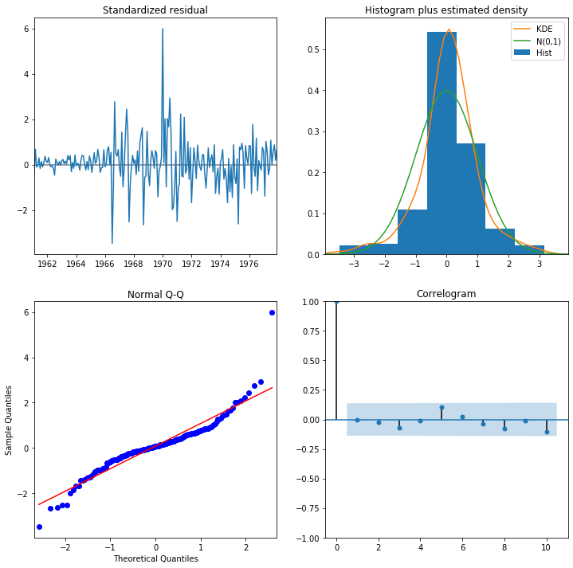

```python
# Summarize residual errors for the chosen ARIMA model
final_model = SARIMAX(time_series, order=final_ns_order, seasonal_order=final_ss_order)
final_results = final_model.fit(disp = False)
print(final_results.summary())
final_results.plot_diagnostics(figsize=(12,12))
plt.show()
```

```python
if (notifyStatus): email_notify("Model Fitting and Evaluation completed! "+datetime.now().strftime('%a %B %d, %Y %I:%M:%S %p'))
```

## Section 5. Finalize Model

After models have been developed and a final model selected, it must be validated and finalized. Validation is an optional part of the process, but one that provides a ‘last check’ to ensure we have not fooled or lied to ourselves.

```python
if (notifyStatus): email_notify("Model Finalization has begun! "+datetime.now().strftime('%a %B %d, %Y %I:%M:%S %p'))
```

### 5.a) Validation via In-sample Data

```python
forecast = final_results.get_prediction(start = -test_size)
mean_forecast = forecast.predicted_mean
confidence_intervals = forecast.conf_int()
```

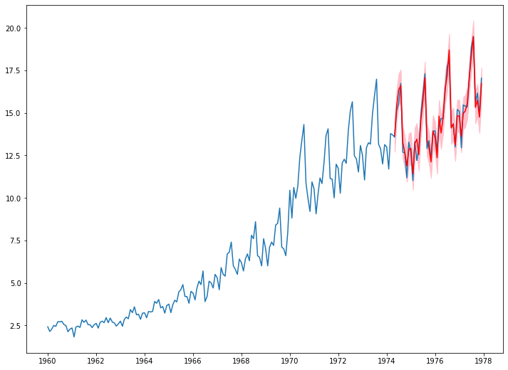

```python
plt.figure(figsize=(12,9))
plt.plot(time_series.index, time_series[target_col], label='observed')
plt.plot(mean_forecast.index, mean_forecast.values, color='red', label='forecast')
plt.fill_between(confidence_intervals.index, confidence_intervals[lower_bound], confidence_intervals[upper_bound], color='pink')
plt.show()
```

```python
# Evaluate RMSE for the validation data
y = time_series[-test_size:]
predictions = mean_forecast.values
rmse = math.sqrt(mean_squared_error(y, predictions))
print('RMSE from the validation data is: %.3f' % rmse)
```

```
RMSE from the validation data is: 0.437
```

### 5.b) Forecasting Out-of-Sample Data

```python
forecast = final_results.get_forecast(steps = test_size)
mean_forecast = forecast.predicted_mean
confidence_intervals = forecast.conf_int()
```

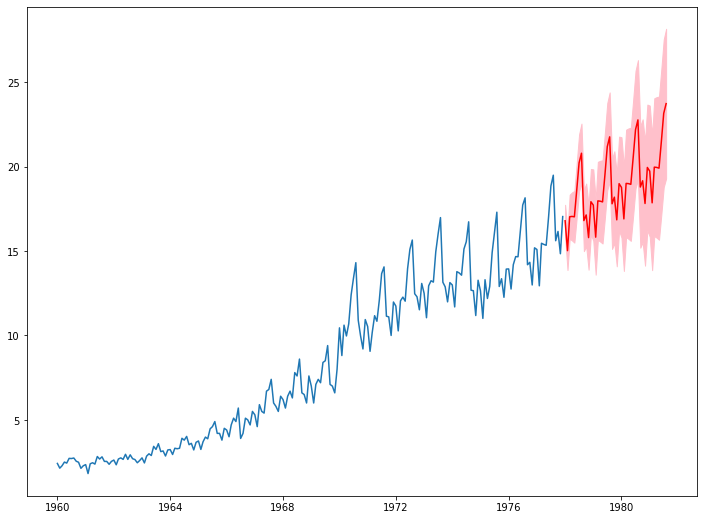

```python
plt.figure(figsize=(12,9))
plt.plot(time_series.index, time_series[target_col], label='observed')
plt.plot(mean_forecast.index, mean_forecast.values, color='red', label='forecast')
plt.fill_between(confidence_intervals.index, confidence_intervals[lower_bound], confidence_intervals[upper_bound], color='pink')
plt.show()
```

```python
if (notifyStatus): email_notify("Model Finalization completed! "+datetime.now().strftime('%a %B %d, %Y %I:%M:%S %p'))
```

```python
print ('Total time for the script:',(datetime.now() - startTimeScript))
```

```
Total time for the script: 1:12:50.600520
```